# Creating Animated Plots in R

Abeer Hasan

2025-04-22

## gganimate: How to Create Plots with Beautiful Animation in R

This document describes how to create animation in R using the “gganimate” R package.

gganimate is an extension of the ggplot2 package for creating animated ggplots. It provides a range of new functionality that can be added to the plot object in order to customize how it should change with time.

## Key features of gganimate:

- transition_*(): defines how the data should be spread out and how it relates to itself across time.
- view(): defines how the positional scales should change along the animation.
- shadow_*(): defines how data from other points in time should be presented in the given point in time.
- enter/exit_*(): defines how new data should appear and how old data should disappear during the course of the animation.
- ease_aes(): defines how different aesthetics should be eased during transitions.

## Prerequisites

```r
# install.packages('gganimate')
# Load required packages and set the default ggplot2 theme to theme_bw():

library(ggplot2)
library(gganimate)
theme_set(theme_bw())

# Warning: package ‘ggplot2’ was built under R version 4.3.3Warning: package ‘gganimate’ was built under R version 4.3.3 No renderer back-end detected. "gganimate" will default to writing frames to separate files
# Consider installing:
# - the `gifski` package for gif output
# - the `av` package for video output
library(gifski) # - the `gifski` package for gif output
```

## Demo dataset

```r
library(gapminder)
head(gapminder)
```

| country | continent | year | lifeExp | pop | gdpPercap |
| --- | --- | --- | --- | --- | --- |
| Afghanistan | Asia | 1952 | 28.801 | 8425333 | 779.4453 |
| Afghanistan | Asia | 1957 | 30.332 | 9240934 | 820.8530 |
| Afghanistan | Asia | 1962 | 31.997 | 10267083 | 853.1007 |
| Afghanistan | Asia | 1967 | 34.020 | 11537966 | 836.1971 |
| Afghanistan | Asia | 1972 | 36.088 | 13079460 | 739.9811 |
| Afghanistan | Asia | 1977 | 38.438 | 14880372 | 786.1134 |

## Exploring the data

```r
str(gapminder)
```

```
## tibble [1,704 × 6] (S3: tbl_df/tbl/data.frame)
##  $ country  : Factor w/ 142 levels "Afghanistan",..: 1 1 1 1 1 1 1 1 1 1 ...
##  $ continent: Factor w/ 5 levels "Africa","Americas",..: 3 3 3 3 3 3 3 3 3 3 ...
##  $ year     : int [1:1704] 1952 1957 1962 1967 1972 1977 1982 1987 1992 1997 ...
##  $ lifeExp  : num [1:1704] 28.8 30.3 32 34 36.1 ...
##  $ pop      : int [1:1704] 8425333 9240934 10267083 11537966 13079460 14880372 12881816 13867957 16317921 22227415 ...
##  $ gdpPercap: num [1:1704] 779 821 853 836 740 ...
```

```r
head(gapminder)
```

| country | continent | year | lifeExp | pop | gdpPercap |
| --- | --- | --- | --- | --- | --- |
| Afghanistan | Asia | 1952 | 28.801 | 8425333 | 779.4453 |
| Afghanistan | Asia | 1957 | 30.332 | 9240934 | 820.8530 |
| Afghanistan | Asia | 1962 | 31.997 | 10267083 | 853.1007 |
| Afghanistan | Asia | 1967 | 34.020 | 11537966 | 836.1971 |
| Afghanistan | Asia | 1972 | 36.088 | 13079460 | 739.9811 |
| Afghanistan | Asia | 1977 | 38.438 | 14880372 | 786.1134 |

```r
summary(gapminder)
```

```
##         country        continent        year         lifeExp
##  Afghanistan:  12   Africa  :624   Min.   :1952   Min.   :23.60
##  Albania    :  12   Americas:300   1st Qu.:1966   1st Qu.:48.20
##  Algeria    :  12   Asia    :396   Median :1980   Median :60.71
##  Angola     :  12   Europe  :360   Mean   :1980   Mean   :59.47
##  Argentina  :  12   Oceania : 24   3rd Qu.:1993   3rd Qu.:70.85
##  Australia  :  12                  Max.   :2007   Max.   :82.60
##  (Other)    :1632
##       pop              gdpPercap
##  Min.   :6.001e+04   Min.   :   241.2
##  1st Qu.:2.794e+06   1st Qu.:  1202.1
##  Median :7.024e+06   Median :  3531.8
##  Mean   :2.960e+07   Mean   :  7215.3
##  3rd Qu.:1.959e+07   3rd Qu.:  9325.5
##  Max.   :1.319e+09   Max.   :113523.1
##
```

```r
table(gapminder$continent) ## Freq Table
```

```
##
##   Africa Americas     Asia   Europe  Oceania
##      624      300      396      360       24
```

```r
## Get the median life expectancy aggregated by continent
aggregate(lifeExp ~ continent, gapminder, median)
```

| continent | lifeExp |
| --- | --- |
| Africa | 47.7920 |
| Americas | 67.0480 |
| Asia | 61.7915 |
| Europe | 72.2410 |
| Oceania | 73.6650 |

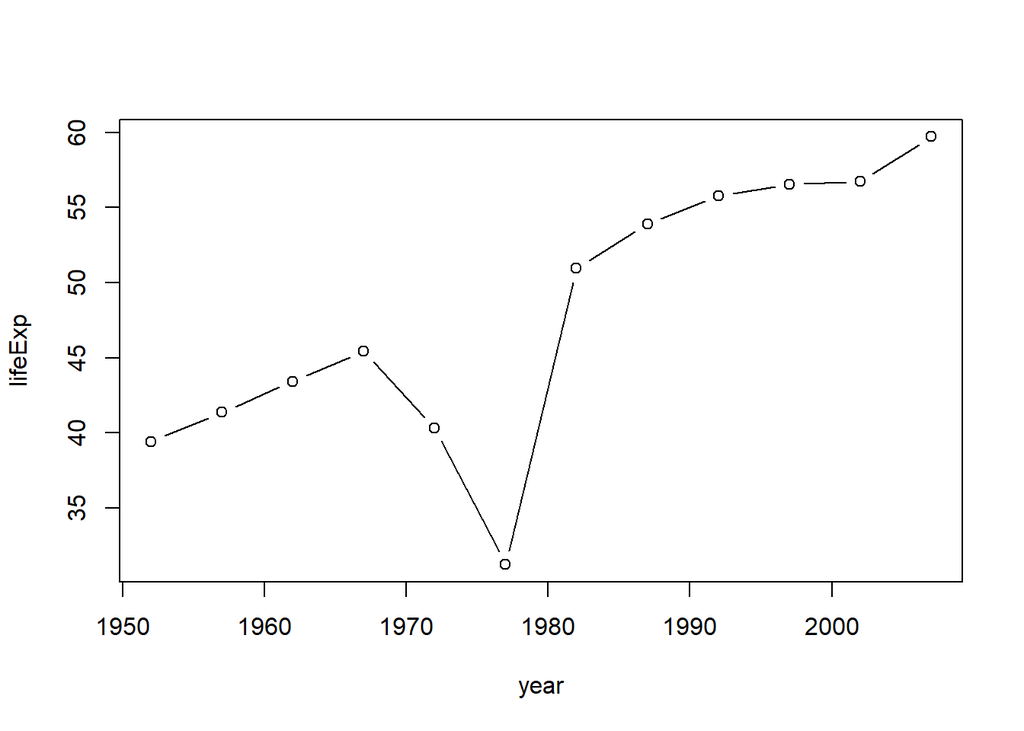

```r
## filter a specific country

plot(lifeExp ~ year, gapminder, subset = country == "Cambodia", type = "b")
```

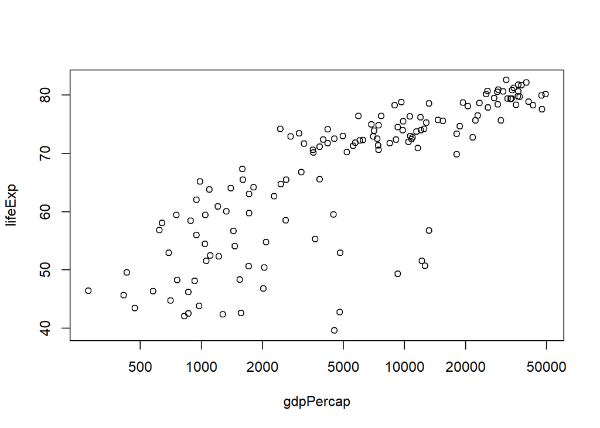

```r
## type = "b": plots Both   Points and lines. The default for plot is to only plot the points

## Question:
## What happened in Cambodia between 1970-1980? Look up the history of the country to see if ## there are political events that explain the change we see in the time series data.


## Filter a specific year
plot(lifeExp ~ gdpPercap, gapminder, subset = year == 2007, log = "x")
```

```r
## Select a specific year and compute median life expectancy for all countries grouped by continent
library(dplyr)
  gapminder %>%
    filter(year == 2007) %>%
    group_by(continent) %>%
    summarise(lifeExp = median(lifeExp))
```

| continent | lifeExp |
| --- | --- |
| Africa | 52.9265 |
| Americas | 72.8990 |
| Asia | 72.3960 |
| Europe | 78.6085 |
| Oceania | 80.7195 |

```r
  # how many unique countries does the data contain, by continent?
  gapminder %>%
    group_by(continent) %>%
    summarize(n_obs = n(), n_countries = n_distinct(country))
```

| continent | n_obs | n_countries |
| --- | --- | --- |
| Africa | 624 | 52 |
| Americas | 300 | 25 |
| Asia | 396 | 33 |
| Europe | 360 | 30 |
| Oceania | 24 | 2 |

## Static plot

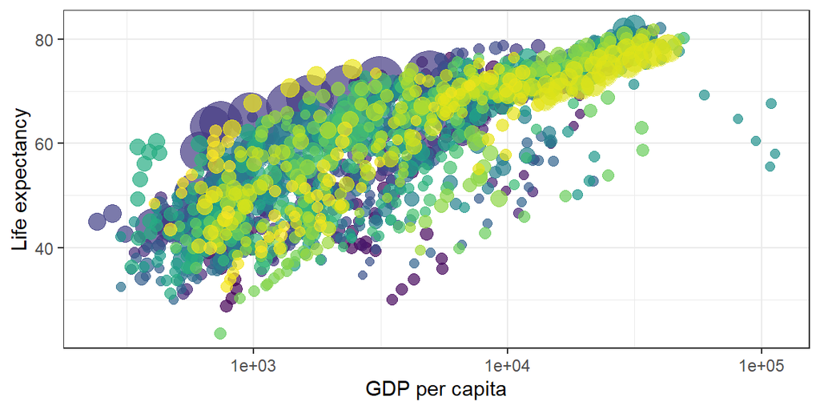

```r
p <- ggplot(
  gapminder,
  aes(x = gdpPercap, y=lifeExp, size = pop, colour = country) ) +
  geom_point(show.legend = FALSE, alpha = 0.7) +
  scale_color_viridis_d() +
  scale_size(range = c(2, 12)) +
  scale_x_log10() +
  labs(x = "GDP per capita", y = "Life expectancy")
p
```

```r
## Question: What does the option alpha do?
## Experiment with different values to find out!

## R Tip:
# The command scale_color_viridis_d() in ggplot2 is used to apply a color scale
# to discrete (categorical) variables using the # Viridis color palette, which is:

#    Colorblind-friendly

#    Perceptually uniform

#    Print-friendly

#    Visually appealing
```

## Transition through distinct states in time

### Key R function:

- transition_time(). The transition length between the states will be set to correspond to the actual time difference between them.
- Label variables: frame_time. Gives the time that the current frame corresponds to.

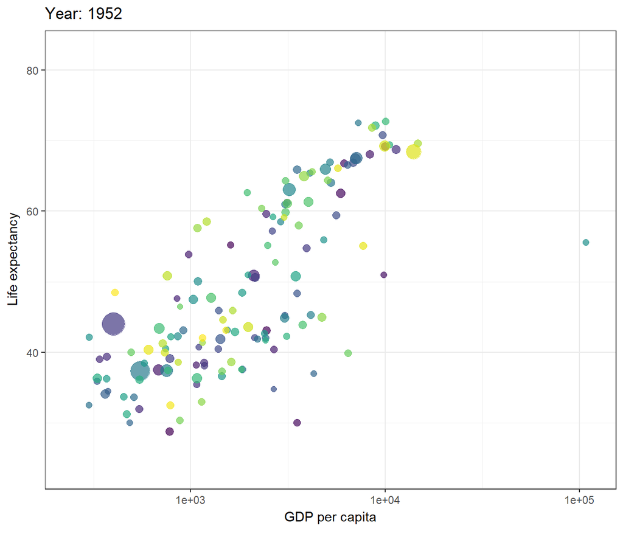

```r
p + transition_time(year) +
  labs(title = "Year: {frame_time}")
```

## Show preceding frames with gradual falloff

This shadow is meant to draw a small wake after data by showing the latest frames up to the current. You can choose to gradually diminish the size and/or opacity of the shadow. The length of the wake is not given in absolute frames as that would make the animation susceptible to changes in the frame-rate. Instead it is given as a proportion of the total length of the animation.

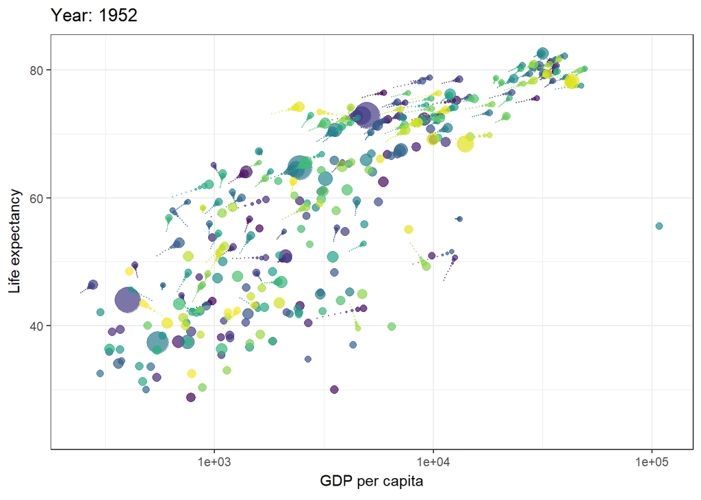

```r
p + transition_time(year) +
  labs(title = "Year: {frame_time}") +
  shadow_wake(wake_length = 0.1, alpha = FALSE)
```

## Show the original data as background marks

This shadow lets you show the raw data behind the current frame. Both past and/or future raw data can be shown and styled as you want.

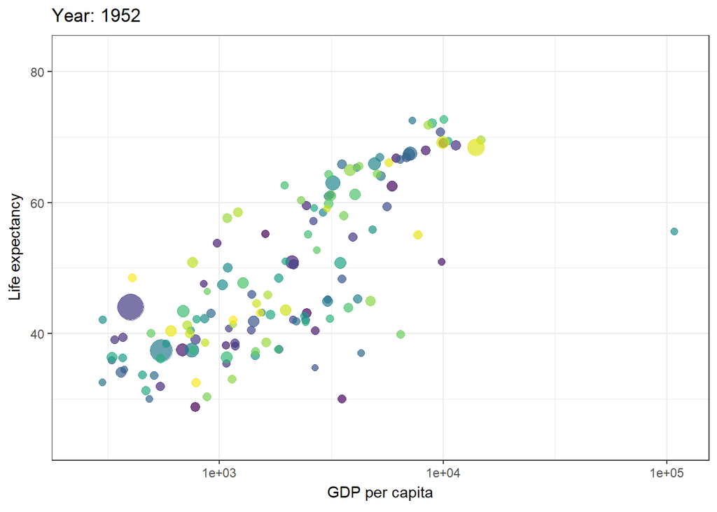

```r
p + transition_time(year) +
  labs(title = "Year: {frame_time}") +
  shadow_mark(alpha = 0.3, size = 0.5)
```

## Another Example Split by Continent

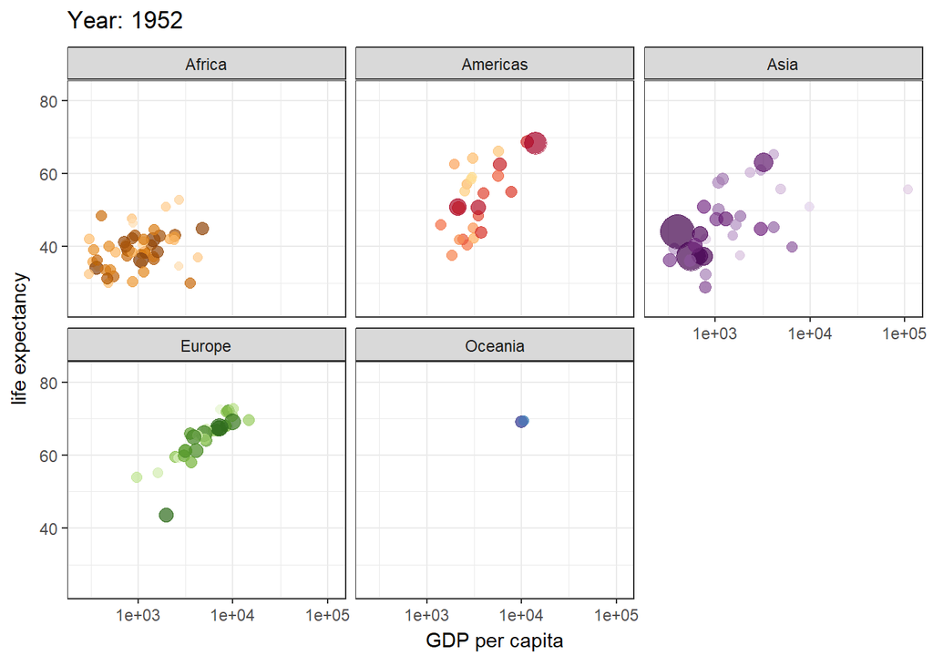

```r
library(gapminder)
ggplot(gapminder, aes(gdpPercap, lifeExp, size = pop, colour = country)) +
  geom_point(alpha = 0.7, show.legend = FALSE) +
  scale_colour_manual(values = country_colors) +
  scale_size(range = c(2, 12)) +
  scale_x_log10() +
  facet_wrap(~continent) +
  # Here comes the gganimate specific bits
  labs(title = 'Year: {frame_time}', x = 'GDP per capita',
       y = 'life expectancy') +
  transition_time(year) +
  ease_aes('linear')
```

## Transition Tools ## Reveal data along a given dimension

This transition allows you to let data gradually appear, based on a given time dimension. Let’s explore with the air quality data.

## Static plot

```r
p <- ggplot(
  airquality,
  aes(Day, Temp, group = Month, color = factor(Month))) +
  geom_line() +
  scale_color_viridis_d() +
  labs(x = "Day of Month", y = "Temperature") +
  theme(legend.position = "top")
p
```

[figure not shown]

## Let data gradually appear

Reveal by day (x-axis) Show points:

```
## `geom_line()`: Each group consists of only one observation.
## ℹ Do you need to adjust the group aesthetic?
## `geom_line()`: Each group consists of only one observation.
## ℹ Do you need to adjust the group aesthetic?
```

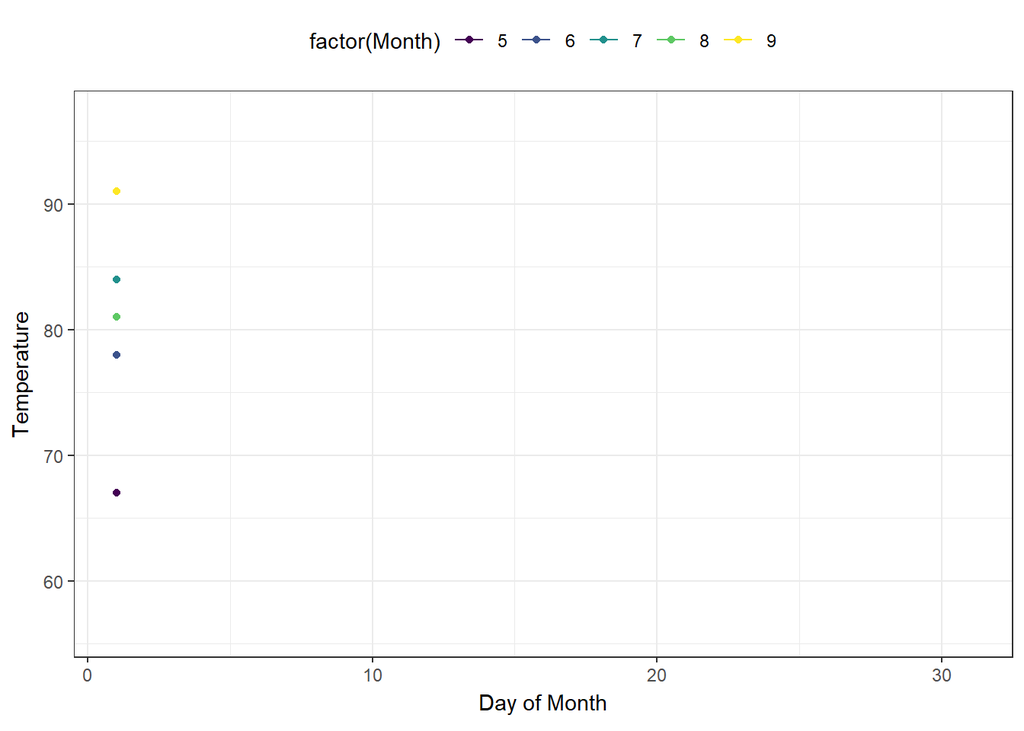

```r
p +
  geom_point() +
  transition_reveal(Day)
```

Points can be kept by giving them a unique group:

```
## `geom_line()`: Each group consists of only one observation.
## ℹ Do you need to adjust the group aesthetic?
## `geom_line()`: Each group consists of only one observation.
## ℹ Do you need to adjust the group aesthetic?
```

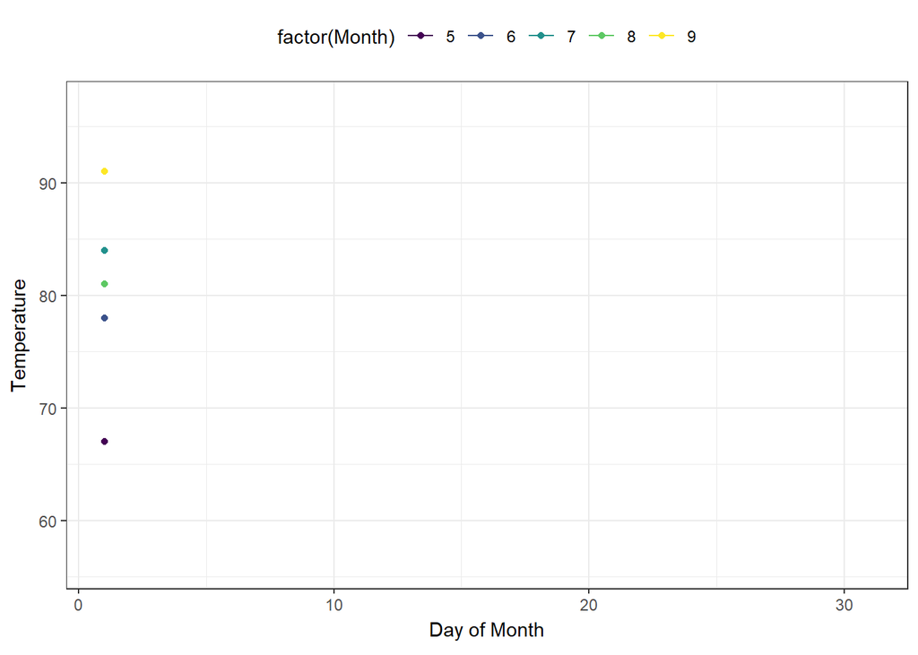

```r
p +
  geom_point(aes(group = seq_along(Day))) +
  transition_reveal(Day)
```

Transition between several distinct stages of the data Data preparation:

```r
library(dplyr)
mean.temp <- airquality %>%
  group_by(Month) %>%
  summarise(Temp = mean(Temp))
mean.temp
```

| Month | Temp |
| --- | --- |
| 5 | 65.54839 |
| 6 | 79.10000 |
| 7 | 83.90323 |
| 8 | 83.96774 |
| 9 | 76.90000 |

## Create a bar plot of mean temperature:

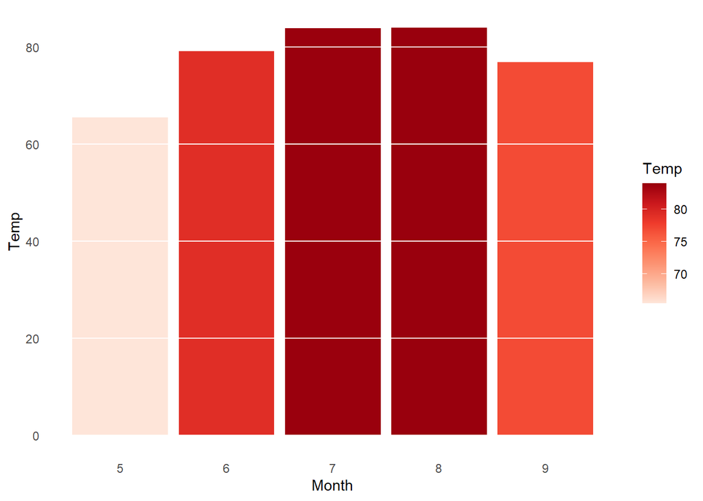

```r
p <- ggplot(mean.temp, aes(Month, Temp, fill = Temp)) +
  geom_col() +
  scale_fill_distiller(palette = "Reds", direction = 1) +
  theme_minimal() +
  theme(
    panel.grid = element_blank(),
    panel.grid.major.y = element_line(color = "white"),
    panel.ontop = TRUE
  )
p
```

## transition_states():

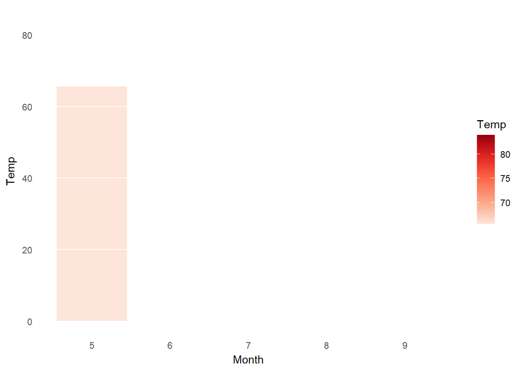

```r
p + transition_states(Month, wrap = FALSE) +
  shadow_mark()
```

## enter_grow() + enter_fade()

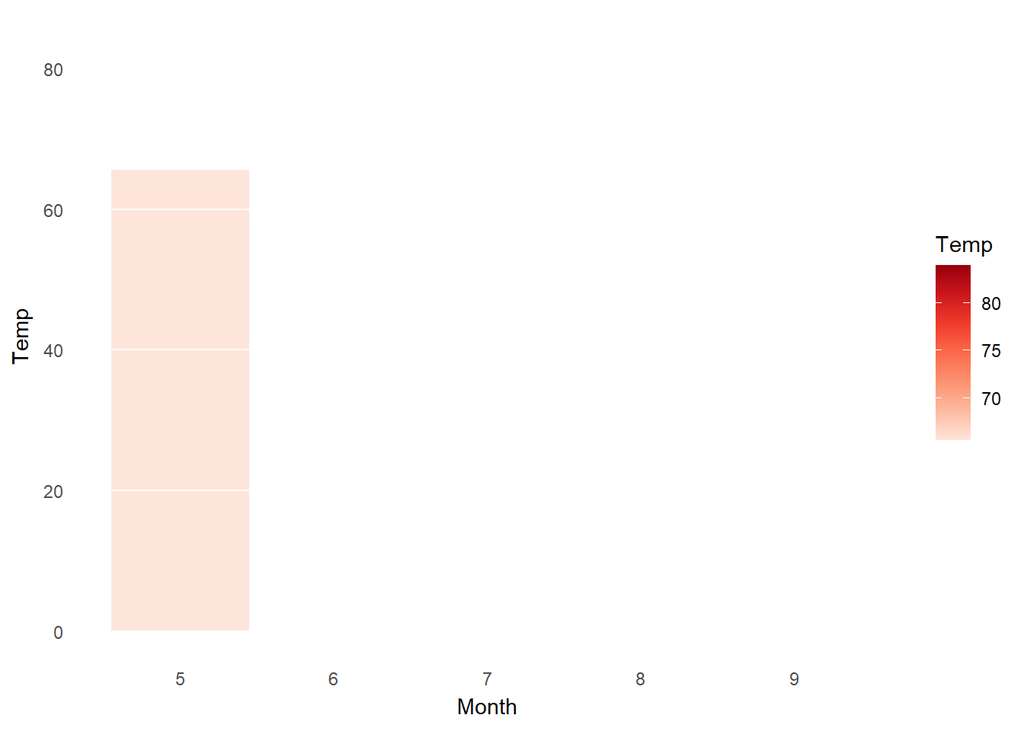

```r
p + transition_states(Month, wrap = FALSE) +
  shadow_mark() +
  enter_grow() +
  enter_fade()
```

## Your Turn!:

Choose a pair of numerical variables from the airquality data or gapminder data, and create a visualization to explore the relation between them. Decide on the appropriate animation and interpret your findings. Are the two variables you picked correlated or not? Explain.

```r
# type your solution here
```